# Лабораторная работа №13

Средства, применяемые при разработке программного обеспечения в ОС UNIX/Linux

Кузнецова С. В.

Российский университет дружбы народов, Москва, Россия

30 апреля 2023

# Информация

## Докладчик

- Кузнецова София Вадимовна
- студент прикладной информатики
- Российский университет дружбы народов

# Выполнение лабораторной работы

## Создание подкаталога, файлов и переход в emacs

В домашнем каталоге создадим подкаталог ~/work/os/lab_prog. После чего создадим в нём файлы: calculate.h, calculate.c, main.c и выполним проверку. Перейдём в emacs.

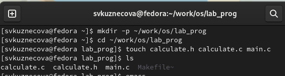

Создание нового подкаталога и файлов в нём

## Перенос первого скрипта

В emacs откроем созданный файл calculate.c и приступим к переносу в него скрипта из файла.

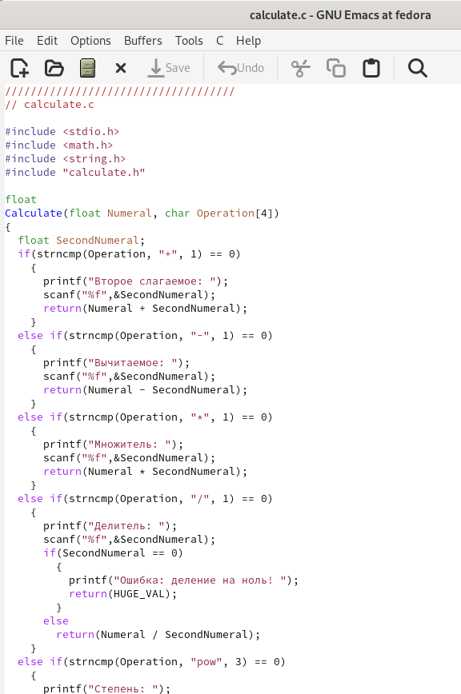

Перенос скрипта для calculate.c

## Перенос второго скрипта

После того как мы перенесли и сохранили скрипт для первого файла, открываем файл calculate.h и также приступим в него скрипта, но уже для второго файла. Выполняем сохранение.

[figure not shown]

Перенос скрипта для calculate.h

## Перенос третьего скрипта

Теперь нам нужно перенести последний третий скрипт в файл main.c. После чего также выполняем сохранение и закрываем emacs.

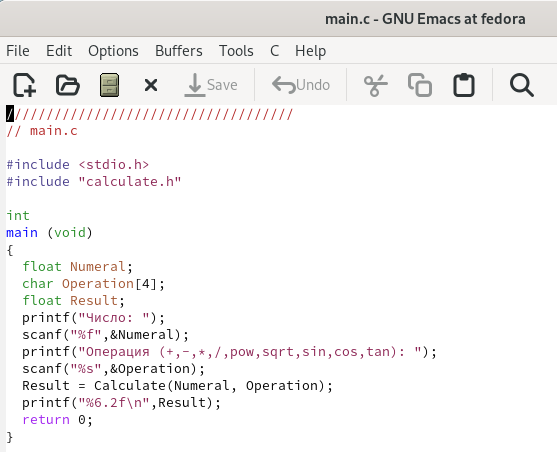

Перенос скрипта для main.c

## Компиляция программы посредством gcc

В терминале выполняем компиляцию программ посредством gcc.

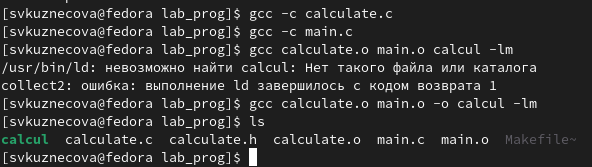

Компиляция программы

## Создание и изменение Makefile

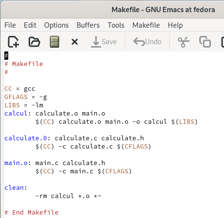

Создание и изменение Makefile

## Отладка программы calcul с помощью gdb

С помощью gdb выполняем отладку программы calcul. После чего запустим программу командой run.

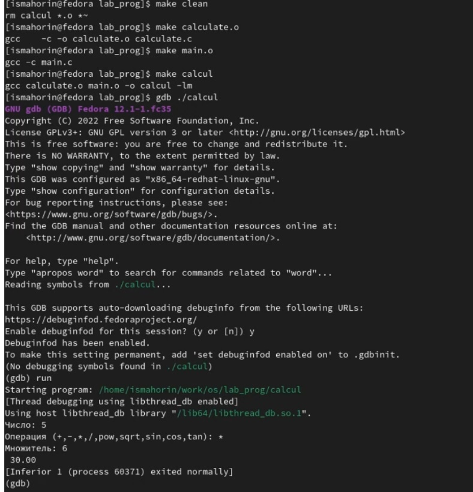

Отладка программы calcul

## Анализ файлов утилитой splint

Воспользовавшись утилитой splint проанализируем коды файлов calculate.c и main.c. C помощью утилиты splint выяснилось, что в файлах calculate.c и main.c присутствует функция чтения scanf, возвращающая целое число (тип int), но эти числа не используются и нигде не сохранятся. Утилита вывела предупреждение о том, что в файле calculate.c происходит сравнение вещественного числа с нулем. Также возвращаемые значения (тип double) в функциях pow, sqrt, sin, cos и tan записываются в переменную типа float, что свидетельствует о потери данных.

## Анализ файла calculate.c утилитой splint

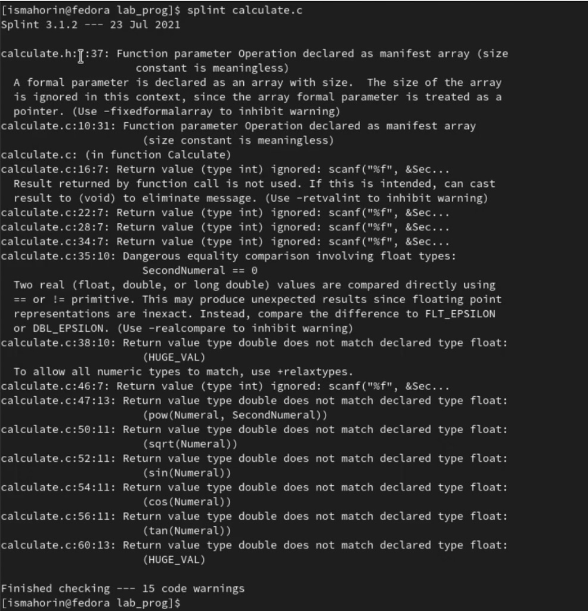

Анализ файла calculate.c

## Анализ файла main.c утилитой splint

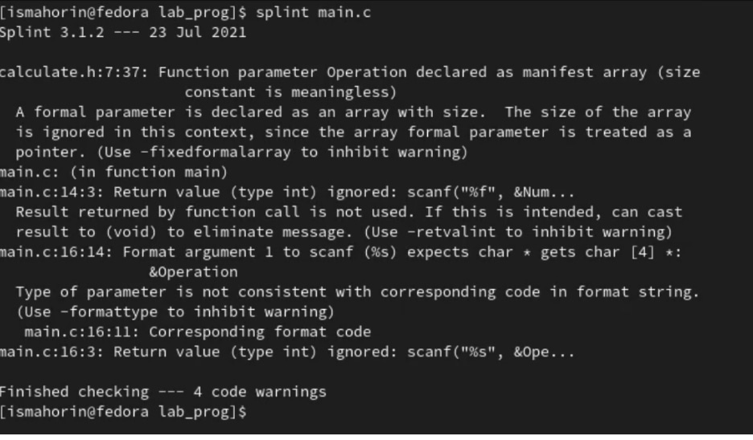

Анализ файла main.c

# Выводы

В ходе выполнения лабораторной работы мы приобрели простейшие навыки разработки, анализа, тестирования и отладки приложений в ОС типа UNIX/Linux на примере создания на языке программирования С калькулятора с простейшими функциями.

Спасибо за внимание!